# smallsets User Guide

## Smallset Timelines

In this vignette, we explain how to use smallsets to build Smallset Timelines. A Smallset Timeline (or Timeline) is a simple visualisation of data preprocessing decisions. More information on Timelines can be found in the Smallset Timeline paper and on YouTube.

- [ACM FAccT paper about Smallset Timelines](https://dl.acm.org/doi/abs/10.1145/3531146.3533175)
- [3-minute YouTube video](https://www.youtube.com/watch?v=_fpn02h3IUo)
- [15-minute YouTube video](https://www.youtube.com/watch?v=I_ksOv6rj1Y)

## Code block legend

Blocks without a border contain code to run.

```r
# run this code
```

Blocks with a blue border contain example preprocessing code not meant to be run.

```r
# don't run this code
```

## Example dataset

In this vignette, we use the synthetic dataset s_data, which is included in smallsets. See `?s_data` for more information.

```r
library(smallsets)

head(s_data)
```

```
  C1    C2 C3  C4   C5    C6    C7    C8
1  2  TRUE 33 199 5.44    NA  0.99    NA
2  3  TRUE 31 161 4.84  6.74  1.24  1.22
3  4 FALSE 33 188 5.97  9.35 -0.04  0.59
4  2 FALSE 24 129 4.33  7.80    NA    NA
5  2  TRUE 32 115 6.64 10.64    NA    NA
6  3  TRUE 22 101 3.93  7.18 -1.12 -0.63
```

## The basics

Each Smallset Timeline is constructed from your dataset and R/Python data preprocessing script. Scripts must contain a series of smallsets comments with snapshot instructions. Your unprocessed dataset (`data`) and commented preprocessing script (`code`) are the only required inputs to `Smallset_Timeline`.

The script s_data_preprocess.R is included in smallsets as an example and needs to be called with `system.file`. Generally, though, you will pass a character string to `code` (e.g., “my_code.R” or “/…/…/my_code.R”).

**Important notes**

- Your dataset must be tabular.
- Your preprocessing code must be contained in a single script.
- Visualisations of data merges, collapses, and switches between the long/wide format are not supported, as smallsets tracks rows by their row names (which are overwritten during these transformations).

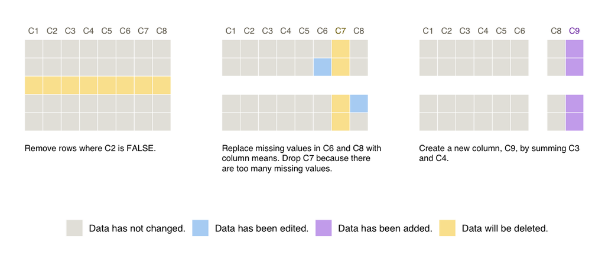

```r
library(smallsets)

set.seed(145)

Smallset_Timeline(data = s_data,
                  code = system.file("s_data_preprocess.R", package = "smallsets"))
```

### Structured comments

Below is the R preprocessing script for s_data (s_data_preprocess.R). It contains several smallsets comments. All comments follow the same formula.

**hash + smallsets + instruction + name of data object + caption[…]caption**

There are four instructions available.

1. start
2. end
3. snap
4. resume

The name of the data object can change throughout the script. The snapshot is taken of the object specified in the comment.

**s_data_preprocess.R**

```r
# smallsets start s_data caption[Remove rows where C2
# is FALSE.]caption
s_data <- s_data[s_data$C2 == TRUE, ]

s_data$C6[is.na(s_data$C6)] <- mean(s_data$C6, na.rm = TRUE)
# smallsets snap s_data caption[Replace missing values in C6 and
# C8 with column means. Drop C7 because there are too many
# missing values.]caption
s_data$C8[is.na(s_data$C8)] <- mean(s_data$C8, na.rm = TRUE)
s_data$C7 <- NULL

s_data$C9 <- s_data$C3 + s_data$C4
# smallsets end s_data caption[Create a new column,
# C9, by summing C3 and C4.]caption
```

### Python example

Python scripts can be passed to the R command `Smallset_Timeline`.

```r
Smallset_Timeline(data = s_data,
                  code = system.file("s_data_preprocess.py", package = "smallsets"))
```

Below is the script s_data_preprocess.py, which does the same thing as s_data_preprocess.R. The smallsets commenting system is the same in Python.

**s_data_preprocess.py**

```python
# smallsets start s_data caption[Remove rows where C2
# is FALSE.]caption
s_data = s_data[s_data["C2"] == True]

s_data["C6"].fillna(value = s_data["C6"].mean(), inplace = True)
# smallsets snap s_data caption[Replace missing values in C6 and
# C8 with column means. Drop C7 because there are too many
# missing values.]caption
s_data["C8"].fillna(value = s_data["C8"].mean(), inplace = True)
s_data = s_data.drop(columns = ["C7"])

s_data["C9"] = s_data["C3"] + s_data["C4"]
# smallsets end s_data caption[Create a new column,
# C9, by summing C3 and C4.]caption
```

## Smallset selection

There are two Smallset decisions to make: how many rows (`rowCount`) and how to select them (`rowSelect`).

If `rowSelect = NULL` (the default setting), rows are selected through a simple random sample. The following code would randomly sample seven rows for the Smallset.

```r
Smallset_Timeline(data = s_data,
                  code = system.file("s_data_preprocess.R", package = "smallsets"),
                  rowCount = 7, rowSelect = NULL)
```

To use the other two selection methods, which are optimisation problems proposed [here](https://dl.acm.org/doi/epdf/10.1145/3531146.3533175#section.5), you will need a [Gurobi license](https://www.gurobi.com/solutions/licensing/) as they rely on the [Gurobi solver](https://www.gurobi.com/solutions/gurobi-optimizer/) v9.1.2 (free academic licenses are available). Richard Schuster’s [“Gurobi installation guide”](https://prioritizr.net/articles/gurobi_installation_guide.html) in the `prioritizr` package provides step-by-step instructions on installing Gurobi in R.

If `rowSelect = 1`, the *coverage* problem is used to select rows. For each snapshot, it finds at least one example of a data change, if there is one. You can return the solution to the console with `rowReturn = TRUE`.

```r
Smallset_Timeline(data = s_data,
                  code = system.file("s_data_preprocess.R", package = "smallsets"),
                  rowCount = 5, rowSelect = 1, rowReturn = TRUE)
```

```
Smallset rows: 27, 42, 95, 96, 99
```

After the optimisation problem is solved once, the solution can be passed to `rowNums` to avoid having to re-solve it with each run of `Smallset_Timeline`.

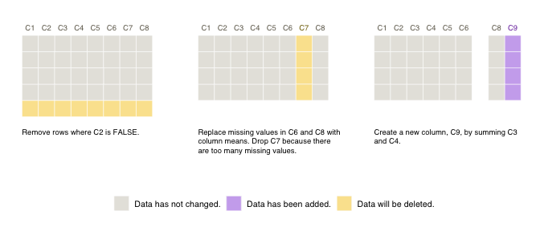

```r
Smallset_Timeline(data = s_data,
                  code = system.file("s_data_preprocess.R", package = "smallsets"),
                  rowCount = 5, rowNums = c(27, 42, 95, 96, 99))
```

Here, the *coverage* solution misses a data edit example in the second snapshot, motivating use of the other selection method (`rowSelect = 2`): the *coverage + variety* optimisation problem, which looks for rows affected by the preprocessing steps differently. **The drawback of `rowSelect = 2` is runtime for large datasets.** One potential workaround to a long runtime is building a Timeline from a sample of the dataset. However, this should be done with caution.

```r
Smallset_Timeline(data = s_data,
                  code = system.file("s_data_preprocess.R", package = "smallsets"),
                  rowSelect = 2, rowReturn = T)
```

```
Smallset rows: 3, 32, 80, 97, 99
```

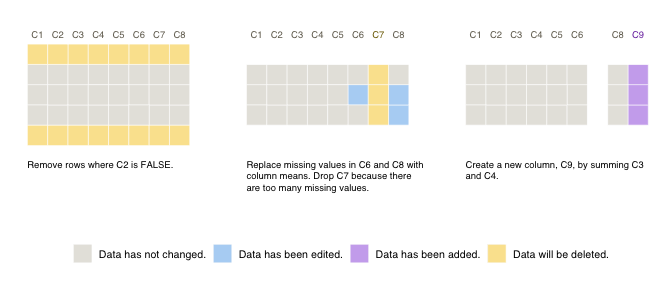